# Análise descritiva dos migrantes qualificados — CGIL, 2024 e 2025

24/10/2026

# 1 Introdução

Este relatório apresenta uma análise descritiva dos registros de autorizações da Coordenação-Geral de Imigração Laboral (CGIL) em 2024 e 2025. A comparação concentra-se nos três primeiros trimestres de cada ano e no perfil do terceiro trimestre de 2025.

# 2 Leitura e preparação dos dados

```r
arquivos <- c("CGIL_CNIg_2024(in).csv", "CGIL_CNIg_2025(in).csv")
if (!all(file.exists(arquivos))) {
  stop("Não encontrei os dois arquivos CSV. Coloque os CSVs na mesma pasta do RMarkdown.")
}
d24 <- read.csv2(arquivos[1], stringsAsFactors = FALSE, fileEncoding = "UTF-8")
d25 <- read.csv2(arquivos[2], stringsAsFactors = FALSE, fileEncoding = "UTF-8")
dados <- bind_rows(d24, d25)
dados$ano <- as.integer(dados$ano)
dados$mes <- as.integer(dados$mes)
dados$trimestre <- ceiling(dados$mes / 3)
kable(data.frame(Ano = c(2024, 2025, "Total"), Registros = c(nrow(d24), nrow(d25), nrow(dados))))
```

| Ano | Registros |
| --- | --- |
| 2024 | 56898 |
| 2025 | 72846 |
| Total | 129744 |

## 2.1 Tratamento dos acentos

Alguns textos já vêm com caracteres corrompidos nos CSVs, como `SÃ£o Paulo`. A função abaixo tenta reconstruir os acentos **somente para apresentação**, preservando os valores originais usados nos filtros. Textos que não puderem ser convertidos permanecem como estão.

```r
corrigir_acentos <- function(x) {
  x <- as.character(x)
  y <- suppressWarnings(iconv(x, from = "UTF-8", to = "latin1", sub = NA))
  Encoding(y) <- "UTF-8"
  valido <- !is.na(y) & !is.na(iconv(y, from = "UTF-8", to = "UTF-8", sub = NA))
  usar <- !is.na(x) & grepl("Ã|Â", x) & valido
  x[usar] <- y[usar]
  x
}
```

# 3 Definição operacional de migrantes qualificados

Consideram-se registros da modalidade CGIL, deferidos e com escolaridade superior ou acima. A escolaridade aparece em dois formatos no período estudado. Para os amparos legais, identificam-se diretamente RN 02, RN 11 e RN 24; os casos de RN 30 são classificados a partir da resolução de origem entre parênteses.

**Importante:** o enquadramento adicional de RN 17 no segundo trimestre de 2025 e RN 40 no terceiro trimestre de 2025 foi obtido por comparação com a máscara de referência. Trata-se de uma **regra operacional de reprodução da RN 30**, não de uma interpretação jurídica comprovada ou regra geral para outros períodos.

```r
escolaridades <- c(
  "5_Superior", "6_PÃ³s-GraduaÃ§Ã£o", "7_Mestrado", "8_Doutorado",
  "Superior Completo", "PÃ³s-GraduaÃ§Ã£o", "Mestrado", "Doutorado"
)
base <- dados %>%
  filter(modalidade == "CGIL", andamento == "DEFERIDO",
         escolaridade %in% escolaridades, trimestre %in% 1:3)

amparo <- ifelse(is.na(base$amparo_legal), "", base$amparo_legal)
base$rn_categoria <- NA_character_
base$rn_categoria[grepl("NORMATIVA\\s+02/2017", amparo, ignore.case = TRUE)] <- "RN 02"
base$rn_categoria[grepl("NORMATIVA\\s+11/2017", amparo, ignore.case = TRUE)] <- "RN 11"
base$rn_categoria[grepl("NORMATIVA\\s+24/2018", amparo, ignore.case = TRUE)] <- "RN 24"
base$eh_rn30 <- grepl("NORMATIVA\\s+30/2018", amparo, ignore.case = TRUE)
base$rn_origem <- suppressWarnings(as.integer(str_match(amparo, "\\(RN\\s*0*([0-9]+)/")[, 2]))

rn30_aceita <- with(base,
  eh_rn30 & (
    (ano == 2024 & rn_origem %in% c(2, 11, 24)) |
    (ano == 2025 & trimestre == 1 & rn_origem %in% c(2, 11, 24)) |
    (ano == 2025 & trimestre == 2 & rn_origem %in% c(2, 11, 24, 17)) |
    (ano == 2025 & trimestre == 3 & rn_origem %in% c(2, 11, 24, 40))
  )
)
base$rn_categoria[rn30_aceita] <- "RN 30"
qualificados <- base %>% filter(!is.na(rn_categoria))
qualificados$rn_categoria <- factor(qualificados$rn_categoria,
                                   levels = c("RN 02", "RN 11", "RN 24", "RN 30"))
cat("Registros classificados nos três primeiros trimestres:", nrow(qualificados))
```

```
## Registros classificados nos três primeiros trimestres: 6684
```

# 4 Distribuição trimestral e comparação com a máscara

A tabela distingue os resultados calculados nos CSVs dos valores publicados na máscara da atividade. As diferenças não foram corrigidas artificialmente no banco de dados.

```r
referencia <- data.frame(
  ano = c(2024L, 2024L, 2024L, 2025L, 2025L, 2025L),
  trimestre = rep(1:3, 2),
  mascara = c(721L, 1286L, 1193L, 1051L, 1100L, 1383L)
)
trimestres <- qualificados %>% count(ano, trimestre, name = "calculado")
comparacao <- referencia %>%
  left_join(trimestres, by = c("ano", "trimestre")) %>%
  mutate(calculado = coalesce(calculado, 0L),
         diferenca = mascara - calculado)
kable(comparacao,
      col.names = c("Ano", "Trimestre", "Máscara", "Calculado", "Diferença (máscara - calculado)"),
      caption = "Comparação dos totais trimestrais")
```

Comparação dos totais trimestrais

| Ano | Trimestre | Máscara | Calculado | Diferença (máscara - calculado) |
| --- | --- | --- | --- | --- |
| 2024 | 1 | 721 | 721 | 0 |
| 2024 | 2 | 1286 | 1286 | 0 |
| 2024 | 3 | 1193 | 1193 | 0 |
| 2025 | 1 | 1051 | 1051 | 0 |
| 2025 | 2 | 1100 | 1085 | 15 |
| 2025 | 3 | 1383 | 1348 | 35 |

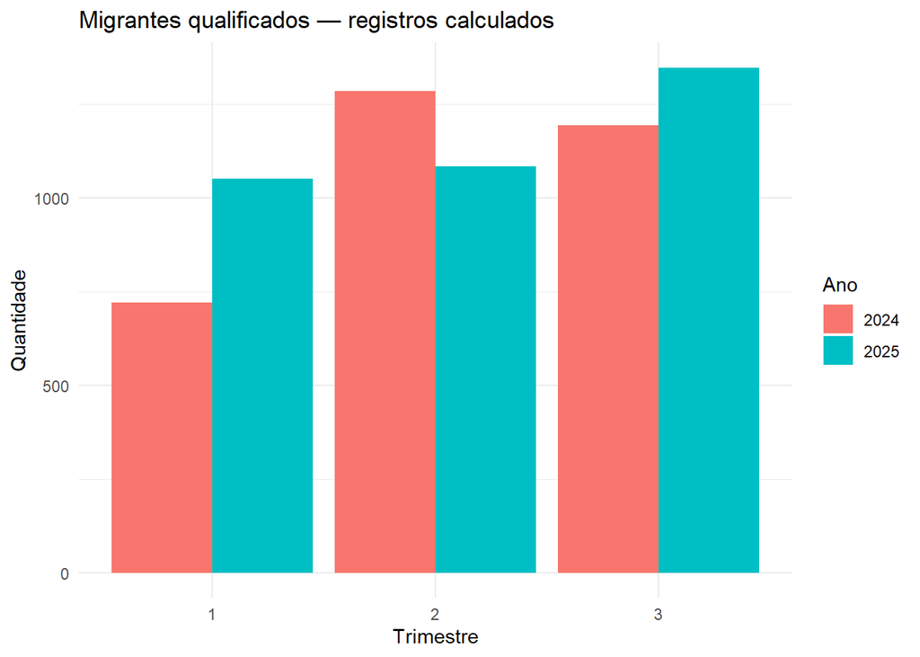

```r
ggplot(comparacao, aes(x = factor(trimestre), y = calculado, fill = factor(ano))) +
  geom_col(position = "dodge") +
  labs(title = "Migrantes qualificados — registros calculados", x = "Trimestre",
       y = "Quantidade", fill = "Ano") +
  theme_minimal()
```

# 5 Comparação do terceiro trimestre

```r
t3 <- comparacao %>% filter(trimestre == 3) %>% arrange(ano)
n24 <- t3$calculado[t3$ano == 2024]
n25 <- t3$calculado[t3$ano == 2025]
variacao <- 100 * (n25 - n24) / n24
kable(t3[, c("ano", "calculado", "mascara")],
      col.names = c("Ano", "Calculado", "Máscara"))
```

| Ano | Calculado | Máscara |
| --- | --- | --- |
| 2024 | 1193 | 1193 |
| 2025 | 1348 | 1383 |

Nos dados classificados pelo procedimento descrito, o terceiro trimestre passou de **1193** registros em 2024 para **1348** em 2025, uma variação de **155** registros (**12.99%**). Esses valores diferem dos totais da máscara em 2025, conforme a tabela anterior.

# 6 Perfil do terceiro trimestre de 2025

```r
t3_2025 <- qualificados %>% filter(ano == 2025, trimestre == 3)
cat("Total analisado no T3/2025:", nrow(t3_2025))
```

```
## Total analisado no T3/2025: 1348
```

## 6.1 Sexo

```r
sexo <- t3_2025 %>%
  mutate(Sexo = case_when(genero == "F" ~ "Feminino",
                         genero == "M" ~ "Masculino",
                         TRUE ~ "Não informado")) %>%
  count(Sexo, name = "Quantidade") %>%
  mutate(Percentual = round(100 * Quantidade / sum(Quantidade), 2))
kable(sexo)
```

| Sexo | Quantidade | Percentual |
| --- | --- | --- |
| Feminino | 300 | 22.26 |
| Masculino | 1048 | 77.74 |

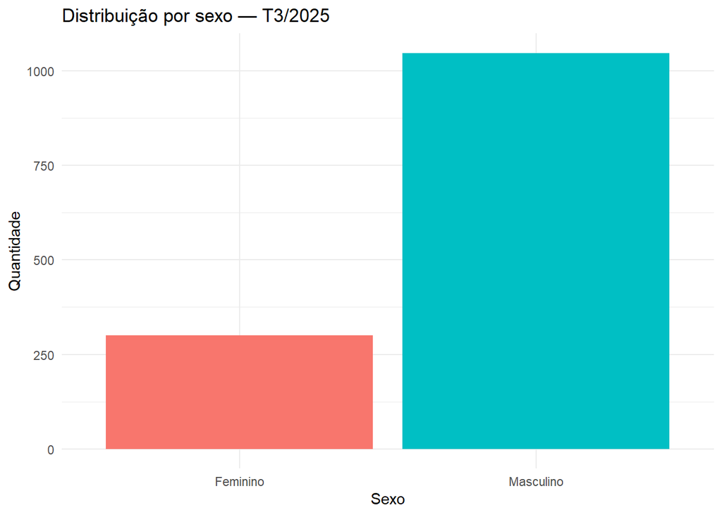

```r
ggplot(sexo, aes(Sexo, Quantidade, fill = Sexo)) +
  geom_col() + theme_minimal() + guides(fill = "none") +
  labs(title = "Distribuição por sexo — T3/2025")
```

## 6.2 Escolaridade

```r
escolaridade <- t3_2025 %>%
  mutate(Escolaridade = case_when(
    escolaridade %in% c("5_Superior", "Superior Completo") ~ "Superior",
    escolaridade %in% c("6_PÃ³s-GraduaÃ§Ã£o", "PÃ³s-GraduaÃ§Ã£o") ~ "Pós-graduação",
    escolaridade %in% c("7_Mestrado", "Mestrado") ~ "Mestrado",
    escolaridade %in% c("8_Doutorado", "Doutorado") ~ "Doutorado",
    TRUE ~ "Outra")) %>%
  count(Escolaridade, name = "Quantidade", sort = TRUE) %>%
  mutate(Percentual = round(100 * Quantidade / sum(Quantidade), 2))
kable(escolaridade)
```

| Escolaridade | Quantidade | Percentual |
| --- | --- | --- |
| Superior | 1031 | 76.48 |
| Mestrado | 285 | 21.14 |
| Doutorado | 32 | 2.37 |

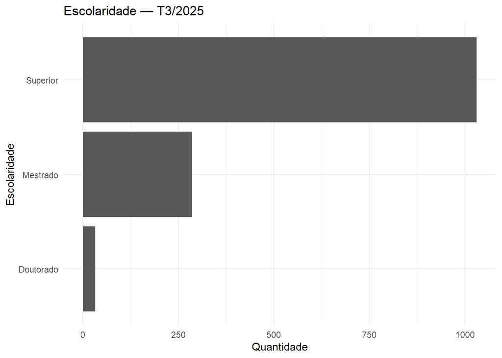

```r
ggplot(escolaridade, aes(reorder(Escolaridade, Quantidade), Quantidade)) +
  geom_col() + coord_flip() + theme_minimal() +
  labs(title = "Escolaridade — T3/2025", x = "Escolaridade")
```

## 6.3 Resolução Normativa

```r
rns <- t3_2025 %>% count(rn_categoria, name = "Quantidade") %>%
  mutate(Percentual = round(100 * Quantidade / sum(Quantidade), 2))
kable(rns, col.names = c("Resolução", "Quantidade", "Percentual (%)"))
```

| Resolução | Quantidade | Percentual (%) |
| --- | --- | --- |
| RN 02 | 782 | 58.01 |
| RN 11 | 177 | 13.13 |
| RN 24 | 15 | 1.11 |
| RN 30 | 374 | 27.74 |

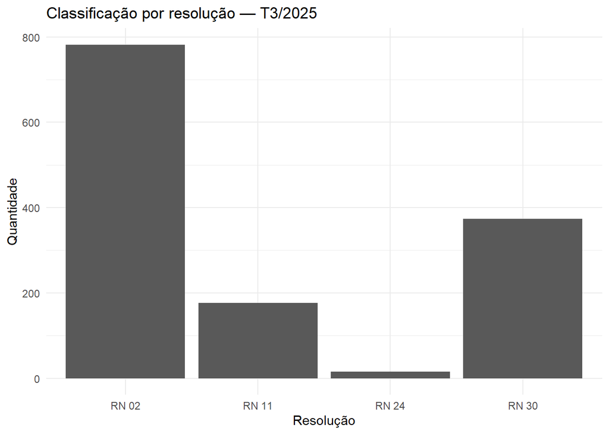

```r
ggplot(rns, aes(rn_categoria, Quantidade)) +
  geom_col() + theme_minimal() +
  labs(title = "Classificação por resolução — T3/2025", x = "Resolução")
```

## 6.4 Distribuição mensal

```r
meses <- t3_2025 %>% count(mes, name = "Quantidade") %>%
  mutate(Mês = factor(mes, levels = 7:9, labels = c("Julho", "Agosto", "Setembro"))) %>%
  select(Mês, Quantidade)
kable(meses)
```

| Mês | Quantidade |
| --- | --- |
| Julho | 395 |
| Agosto | 407 |
| Setembro | 546 |

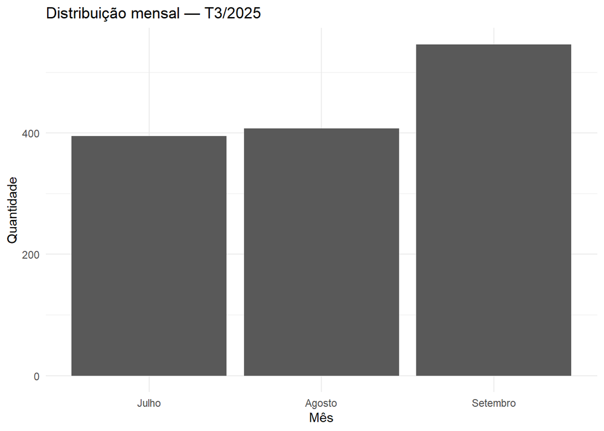

```r
ggplot(meses, aes(Mês, Quantidade)) + geom_col() + theme_minimal() +
  labs(title = "Distribuição mensal — T3/2025")
```

## 6.5 Principais países

```r
paises <- t3_2025 %>%
  filter(!is.na(pais), pais != "") %>%
  count(pais, sort = TRUE, name = "Quantidade") %>%
  slice_head(n = 10) %>%
  mutate(País = corrigir_acentos(pais)) %>%
  select(País, Quantidade)
kable(paises)
```

| País | Quantidade |
| --- | --- |
| CHINA | 722 |
| FRANÇA | 62 |
| ÍNDIA | 61 |
| JAPÃO | 58 |
| ESTADOS UNIDOS | 51 |
| MÉXICO | 39 |
| CORÉIA DO SUL | 38 |
| ESPANHA | 31 |
| ALEMANHA | 27 |
| ITÁLIA | 25 |

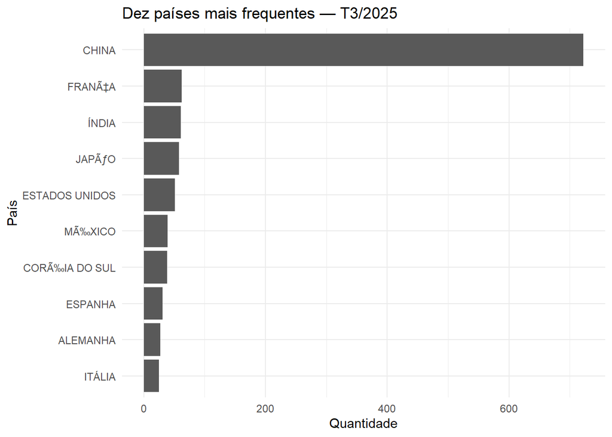

```r
ggplot(paises, aes(reorder(País, Quantidade), Quantidade)) +
  geom_col() + coord_flip() + theme_minimal() +
  labs(title = "Dez países mais frequentes — T3/2025", x = "País")
```

## 6.6 Unidade da Federação

```r
ufs <- t3_2025 %>%
  filter(!is.na(uf_estrangeiro), uf_estrangeiro != "") %>%
  count(uf_estrangeiro, sort = TRUE, name = "Quantidade") %>%
  mutate(UF = corrigir_acentos(uf_estrangeiro)) %>%
  select(UF, Quantidade)
kable(ufs, caption = "Distribuição por Unidade da Federação — T3/2025")
```

Distribuição por Unidade da Federação — T3/2025

| UF | Quantidade |
| --- | --- |
| São Paulo | 780 |
| Rio de Janeiro | 181 |
| Bahia | 99 |
| Minas Gerais | 81 |
| Paraná | 42 |
| Santa Catarina | 30 |
| Rio Grande do Sul | 22 |
| Distrito Federal | 18 |
| Espírito Santo | 18 |
| Ceará | 16 |
| Amazonas | 15 |
| Alagoas | 10 |
| Goiás | 9 |
| Pernambuco | 8 |
| Rio Grande do Norte | 8 |
| Pará | 4 |
| Amapá | 2 |
| Mato Grosso | 2 |
| Mato Grosso do Sul | 1 |
| Paraíba | 1 |
| Sergipe | 1 |

## 6.7 Ocupações mais frequentes

```r
ocupacoes <- t3_2025 %>%
  filter(!is.na(descricao_cbo), descricao_cbo != "") %>%
  count(descricao_cbo, sort = TRUE, name = "Quantidade") %>%
  slice_head(n = 10) %>%
  mutate(Ocupação = corrigir_acentos(descricao_cbo)) %>%
  select(Ocupação, Quantidade)
kable(ocupacoes, caption = "Dez ocupações mais frequentes — T3/2025")
```

Dez ocupações mais frequentes — T3/2025

| Ocupação | Quantidade |
| --- | --- |
| Gerente de produção e operações | 67 |
| Gerente de vendas | 59 |
| Gerente comercial | 49 |
| Diretor geral de empresa e organizações (exceto de interesse público) | 45 |
| Gerente administrativo | 45 |
| Analista de negócios | 43 |
| Diretor administrativo | 43 |
| Gerente financeiro | 42 |
| Diretor de planejamento estratégico | 39 |
| Administrador | 36 |

# 7 Conferência da RN 30

```r
conf_rn30 <- qualificados %>%
  filter(ano == 2025, rn_categoria == "RN 30") %>%
  count(trimestre, name = "Calculado") %>%
  left_join(data.frame(trimestre = 1:3, Referência = c(263L, 324L, 374L)),
            by = "trimestre") %>%
  mutate(Diferença = Referência - Calculado)
kable(conf_rn30)
```

| trimestre | Calculado | Referência | Diferença |
| --- | --- | --- | --- |
| 1 | 263 | 263 | 0 |
| 2 | 324 | 324 | 0 |
| 3 | 374 | 374 | 0 |

# 8 Limitações metodológicas

A máscara de referência informa, para 2025, **1.051**, **1.100** e **1.383** registros nos trimestres 1, 2 e 3. A classificação aplicada aos CSVs pode apresentar totais inferiores, sobretudo nas RN 02, RN 11 e RN 24. Não há informação suficiente no campo `amparo_legal` para identificar de modo inequívoco quais registros adicionais deveriam ser incluídos nessas categorias. Por esse motivo, **os totais da máscara são exibidos como referência, mas não substituem os resultados efetivamente calculados**.

A regra específica usada para RN 30 em 2025 foi identificada por comparação com a máscara e deve ser entendida como ajuste operacional deste exercício, não como critério jurídico independente.

# 9 Conclusão

O estudo descreveu a evolução trimestral dos registros classificados como migrantes qualificados e o perfil dos trabalhadores no terceiro trimestre de 2025. As tabelas e gráficos permitem observar a distribuição por sexo, escolaridade, resolução, mês, país, UF e ocupação. A comparação com a máscara também evidenciou a importância de documentar os critérios de seleção: pequenas diferenças na interpretação do amparo legal podem alterar os totais e, consequentemente, a análise entre períodos.